# Assignment 2: Hand Gesture Recognition [50 Pt]

### Part (i) - [2pt EXPLORATORY]

Here is the code to load the AlexNet network, with pretrained weights. When you first run the code, PyTorch will download the pretrained weights from the internet.

```python
import torchvision.models
alexnet = torchvision.models.alexnet(pretrained=True)
```

The alexnet model is split up into two components: *alexnet.features* and *alexnet.classifier*. The first neural network component, *alexnet.features*, is used to compute convolutional features, which are taken as input in *alexnet.classifier*.

The neural network alexnet.features expects an image tensor of shape Nx3x224x224 as input and it will output a tensor of shape Nx256x6x6 . (N = batch size).

Compute the AlexNet features for each of your training, validation, and test data. Here is an example code snippet showing how you can compute the AlexNet features for some images (your actual code might be different):

```python
# img = ... a PyTorch tensor with shape [N,3,224,224] containing hand images ...
features = alexnet.features(img)
```

**Save the computed features**. You will be using these features as input to your neural network in Part (ii), and you do not want to re-compute the features every time. Instead, run *alexnet.features* once for each image, and save the result.

```python
# TO BE COMPLETED


# Function to get AlexNet features
def get_alexnet_features(model, data_loader):
    model.eval()
    all_features = []

    with torch.no_grad():
        for imgs, labels in data_loader:
            features = model.features(imgs)
            all_features.append(features)

    return torch.cat(all_features, dim=0)

# Compute AlexNet features for training data
train_features = get_alexnet_features(alexnet, train_loader)

# Compute AlexNet features for validation data
val_features = get_alexnet_features(alexnet, val_loader)

# Assuming you have a test_loader for your test data
# Compute AlexNet features for test data
test_features = get_alexnet_features(alexnet, test_loader)

# Save the computed features to files
torch.save(train_features, 'train_features.pth')
torch.save(val_features, 'val_features.pth')
torch.save(test_features, 'test_features.pth')
```

### Part (ii) - [2pt MODEL]

Build a convolutional neural network model that takes as input these AlexNet features, and makes a prediction. Your model should be a subclass of nn.Module.

Explain your choice of neural network architecture: how many layers did you choose? What types of layers did you use: fully-connected or convolutional? What about other decisions like pooling layers, activation functions, number of channels / hidden units in each layer?

Here is an example of how your model may be called:

```python
# features = ... load precomputed alexnet.features(img) ...
output = model(features)
prob = F.softmax(output)
```

```python
# TO BE COMPLETED

# TO BE COMPLETED

class CustomClassifier(nn.Module):
    def __init__(self):
        """
        Constructor for the CustomClassifier class.

        This neural network consists of three fully connected (linear) layers.
        The first layer has 256*6*6 input features, the second layer
        has 4500 hidden units, and the third layer has 9 output units.

        Activation functions (ReLU) are applied after the first two layers.
        """
        super(CustomClassifier, self).__init__()

        # First fully connected layer
        self.fc1 = nn.Linear(256*6*6, 4500)

        # Second fully connected layer
        self.fc2 = nn.Linear(4500, 4500)

        # Third fully connected layer (output layer)
        self.fc3 = nn.Linear(4500, 9)

    def forward(self, x):
        """
        Forward method that defines the forward pass of the neural network.

        Applies the linear transformations defined in the
        constructor along with ReLU activations.

        Parameters:
        - x: Input tensor of shape (batch_size, 256*6*6)

        Returns:
        - Output tensor of shape (batch_size, 9)
        """
        x = x.view(-1, 256*6*6)  # Flatten the input tensor
        x = F.relu(self.fc1(x))  # ReLU activation first fully connected layer
        x = F.relu(self.fc2(x))  # ReLU activation second fully connected layer
        x = self.fc3(x)          # Output layer without activation function
        return x
```

```python
'''
PROVIDE YOUR ANSWER BELOW
---------------------------------------------------------------------------

Considering the context of transfer learning using AlexNet features,
the choice of the neural network architecture involves building upon the
features extracted by AlexNet.

AlexNet Features:
The initial layers of AlexNet consist of convolutional layers that are
effective at capturing hierarchical features from images.

These features, obtained from the AlexNet model,
serve as the input to the custom classifier.

Custom Classifier Architecture:
Linear Layers: The custom classifier consists of three fully connected
(linear) layers (fc1, fc2, and fc3).

Activation Function: Rectified Linear Unit (ReLU) activation functions are
applied after the first two fully connected layers to introduce non-linearity.

Choice of Layers:
The decision to use only linear layers in the custom classifier is based on
the fact that the features obtained from AlexNet already represent high-level
abstractions, and additional convolutional layers may not provide
significant benefits in this context.

Including convolutional layers in this case is optional and would depend on
the specific characteristics of the dataset and the desired level of
abstraction in the custom classifier.

Pooling Layers:
Since AlexNet already incorporates pooling layers in its architecture,
additional pooling layers are not explicitly added to the custom classifier.

Number of Hidden Units:
The first fully connected layer (fc1) has 4500 hidden units, and the second
fully connected layer (fc2) also has 4500 hidden units.
The output layer (fc3) has 9 units, corresponding to the number of classes
in the target classification task.

In conlcusion, the custom classifier extends the features extracted by AlexNet
with fully connected layers and ReLU activations, leveraging the hierarchical
representations learned by the convolutional layers of AlexNet.
This architecture balances the complexity of the model while utilizing
the transfer learning benefits of the pre-trained AlexNet.

--------------------------------------------------------------------------



'''
```

### Part (iii) - [1pt MODEL]

Train your new network, including any hyperparameter tuning. Plot and submit the training curve of your best model only.

Note: Depending on how you are caching (saving) your AlexNet features, PyTorch might still be tracking updates to the **AlexNet weights**, which we are not tuning. One workaround is to convert your AlexNet feature tensor into a numpy array, and then back into a PyTorch tensor.

```python
tensor = torch.from_numpy(tensor.detach().numpy())
```

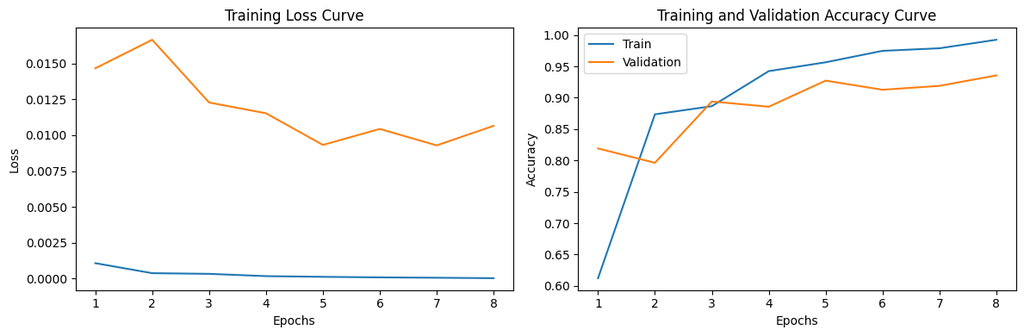

```
Final Training Accuracy: 0.9923529411764705
Final Validation Accuracy: 0.9355509355509355
```

```python
'''
-------------------------------------------------------------
After trying different hyperparameters,
the best parameter set is being presented here.

------------------------------------------------------------

'''

def train(model, train_loader, val_loader, num_epochs):
    criterion = nn.CrossEntropyLoss()
    optimizer = optim.SGD(model.parameters(), lr=0.01, momentum=0.9)

    train_losses, train_acc, val_acc, val_loss = [], [], [], []

    # Training loop
    for epoch in range(num_epochs):
        epoch_loss = 0.0
        correct_train = 0
        total_train = 0

        for imgs, labels in train_loader:
            imgs = alexnet.features(imgs)

            out = model(imgs)
            loss = criterion(out, labels)

            optimizer.zero_grad()
            loss.backward()
            optimizer.step()

            # Save the current training information
            epoch_loss += loss.item() / batch_size  # Adjusted for batch size

            pred_train = out.max(1, keepdim=True)[1]
            correct_train += pred_train.eq(labels.view_as(pred_train)).sum().item()
            total_train += imgs.shape[0]

        train_accuracy = correct_train / total_train
        epoch_loss /= len(train_loader.dataset)
        val_err, vl = get_accuracy_alex(model, val_loader)
        train_losses.append(epoch_loss)  # Append loss to losses at each iteration

        val_loss.append(vl)
        train_acc.append(train_accuracy)
        val_acc.append(1- val_err)

        # Print the training information after each epoch
        print(f'Epoch {epoch + 1}/{num_epochs}, Training Loss: {epoch_loss:.4f}, Validation Loss: {vl:.4f}, Training Accuracy: {train_accuracy:.4f}, Validation Accuracy: {1- val_err:.4f}')

    # Plotting after the training loop
    plt.figure(figsize=(12, 4))

    plt.subplot(1, 2, 1)
    plt.plot(range(1, num_epochs + 1), train_losses, label="Train")
    plt.plot(range(1, num_epochs + 1), val_loss, label="Validation")
    plt.xlabel("Epochs")
    plt.ylabel("Loss")
    plt.title("Training Loss Curve")

    plt.subplot(1, 2, 2)
    plt.plot(range(1, num_epochs + 1), train_acc, label="Train")
    plt.plot(range(1, num_epochs + 1), val_acc, label="Validation")
    plt.xlabel("Epochs")
    plt.ylabel("Accuracy")
    plt.title("Training and Validation Accuracy Curve")

    plt.tight_layout()
    plt.legend(loc='best')
    plt.show()

    print("Final Training Accuracy: {}".format(train_acc[-1]))
    print("Final Validation Accuracy: {}".format(val_acc[-1]))


model = CustomClassifier()


# Train the model
train(model, train_loader, val_loader, num_epochs=8)
```

### Part (iv) - [2pt RESULTS]

Report the test accuracy of your best model. How does the test accuracy compare to Part 3(iv) without transfer learning?

```python
# TO BE COMPLETED

err,loss= get_accuracy_alex(model, test_loader)

print(f'Transfer Learning - Test Error: {err * 100:.2f}%')
print(f'Transfer Learning - Test Accuracy: {100 - err * 100:.2f}%')
print(f' Transfer Learning - Test Loss: {loss:.4f}')
```

```
Transfer Learning - Test Error: 6.40%
Transfer Learning - Test Accuracy: 93.60%
 Transfer Learning - Test Loss: 0.0088
```

```python
'''
PROVIDE YOUR ANSWER BELOW

----------------------------------------------------------------------------
GestureCNN (without transfer learning):
Test Error: 22.00%
Test Accuracy: 78.00%
Test Loss: 1.0190


Transfer Learning:
Test Error: 6.40%
Test Accuracy: 93.60%
Test Loss: 0.0088


The model with transfer learning outperforms the GestureCNN model
without transfer learning. The transfer learning model achieved a
significantly higher test accuracy of 93.60%, while the GestureCNN model
achieved a lower accuracy of 78.00%. Transfer learning allows the model to
leverage knowledge learned from a pre-trained model on a different task,
leading to better generalization and performance on the target task.



'''
```